# 2_Processing results and plotting

```python
import oemof.solph as solph
import oemof.outputlib as outputlib
import pickle
import os
import pandas as pd
import matplotlib.pyplot as plt
from matplotlib.dates import DateFormatter, YearLocator, MonthLocator
import matplotlib
import oemof_visio as oev
%matplotlib inline
matplotlib.rcParams['figure.figsize'] = [20.0, 7.0]
```

### Recommended way: Restore the whole energysystem with results

```python
energysystem = solph.EnergySystem()
energysystem.restore(dpath=None, filename=None)
```

```
'Attributes restored from: /home/local/RL-INSTITUT/jann.launer/.oemof/dumps/es_dump.oemof'
```

### Alternative way (which we will not use now): load a dictionary you have saved before

```python
results_filename = "results_dict.pickle"
results_dict = pickle.load(open(results_filename,'rb'))
# print(results_dict.keys())
```

### Convert keys to strings and print all keys

```python
# print(energysystem.results['main'].keys())
string_results = outputlib.views.convert_keys_to_strings(energysystem.results['main'])
print(string_results.keys())
```

[output not shown]

### Use the outputlib to collect all the flows into and out of the electricity bus

Collect all flows into and out of the electricity bus by using outputlib.views.node()

```python
node_results_bel = outputlib.views.node(energysystem.results['main'], 'bel')
```

What we will be working with now is a pandas dataframe. Have a look at these links to learn about pandas, especially the last one (pandas in 10min):  
https://pandas.pydata.org/  
http://pandas.pydata.org/pandas-docs/stable/  
http://pandas.pydata.org/pandas-docs/stable/10min.html

```python
df = node_results_bel['sequences']
df.head(2)
```

|  | ((bel, demand_el), flow) | ((bel, excess_el), flow) | ((bel, heat_pump), flow) | ((pp_chp, bel), flow) | ((pp_coal, bel), flow) | ((pp_gas, bel), flow) | ((pp_lig, bel), flow) | ((pp_oil, bel), flow) | ((pv, bel), flow) | ((wind, bel), flow) |
| --- | --- | --- | --- | --- | --- | --- | --- | --- | --- | --- |
| 2016-01-01 00:00:00 | 52.169653 | 0.0 | 0.821571 | 2.559823 | 20.2 | 0.0 | 11.8 | 0.0 | 0.0 | 18.4314 |
| 2016-01-01 01:00:00 | 52.169653 | 0.0 | 0.911379 | 2.450731 | 20.2 | 0.0 | 11.8 | 0.0 | 0.0 | 18.6303 |

### Use pandas functionality to create a plot of all the columns of the dataframe

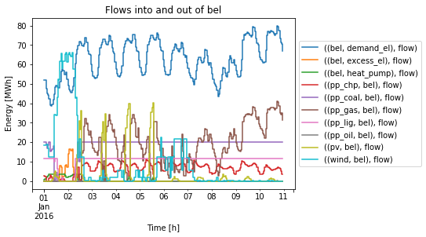

```python
ax = df.plot(kind='line', drawstyle='steps-post')
ax.set_xlabel('Time [h]')
ax.set_ylabel('Energy [MWh]')
ax.set_title('Flows into and out of bel')
ax.legend(loc='center left', bbox_to_anchor=(1.0, 0.5)) # place legend outside of plot
plt.show()
```

### oemof visio provides a function that collects the column names for in and outflows as lists in a dictionary

```python
in_out_dictionary = oev.plot.divide_bus_columns('bel', df.columns)
in_cols = in_out_dictionary['in_cols']
out_cols = in_out_dictionary['out_cols']
```

This allows us to get the all the columns that are outflows:

```python
df[out_cols].head(2)
```

|  | ((bel, demand_el), flow) | ((bel, excess_el), flow) | ((bel, heat_pump), flow) |
| --- | --- | --- | --- |
| 2016-01-01 00:00:00 | 52.169653 | 0.0 | 0.821571 |
| 2016-01-01 01:00:00 | 52.169653 | 0.0 | 0.911379 |

We can get any column of the dataframe by providing its label as a list

```python
bel_to_demand_el = [(('bel', 'demand_el'), 'flow')] #  this is a list with one element
df[bel_to_demand_el].head(2)
```

|  | ((bel, demand_el), flow) |
| --- | --- |
| 2016-01-01 00:00:00 | 52.169653 |
| 2016-01-01 01:00:00 | 52.169653 |

### Plot only outflows

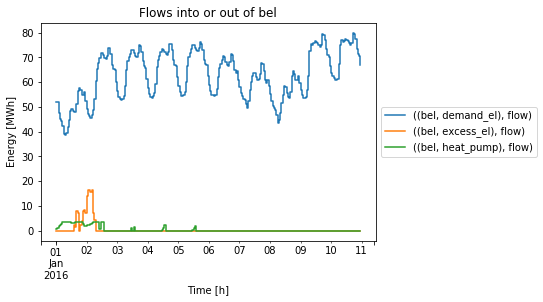

```python
ax = df[out_cols].plot(kind='line', drawstyle='steps-post')
ax.set_xlabel('Time [h]')
ax.set_ylabel('Energy [MWh]')
ax.set_title('Flows into or out of bel')
ax.legend(loc='center left', bbox_to_anchor=(1.0, 0.5)) # place legend outside of plot
plt.show()
```

### Use the functions of oemof_visio to create plots

See also: oemof_examples/examples/oemof_0.2/plotting_examples/storage_investment_plot.py

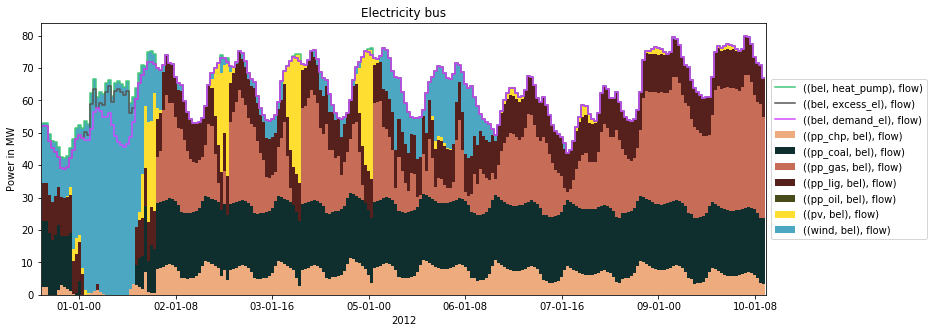

```python
inorder = [(('pp_chp', 'bel'), 'flow'),
             (('pp_coal', 'bel'), 'flow'),
             (('pp_gas', 'bel'), 'flow'),
             (('pp_lig', 'bel'), 'flow'),
             (('pp_oil', 'bel'), 'flow'),
             (('pv', 'bel'), 'flow'),
             (('wind', 'bel'), 'flow')]

outorder = [(('bel', 'demand_el'), 'flow'),
             (('bel', 'excess_el'), 'flow'),
             (('bel', 'heat_pump'), 'flow')]

cdict = {(('pp_chp', 'bel'), 'flow'): '#eeac7e',
        (('pp_coal', 'bel'), 'flow'): '#0f2e2e',
        (('pp_gas', 'bel'), 'flow'): '#c76c56',
        (('pp_lig', 'bel'), 'flow'): '#56201d',
        (('pp_oil', 'bel'), 'flow'): '#494a19',
        (('pv', 'bel'), 'flow'): '#ffde32',
        (('wind', 'bel'), 'flow'): '#4ca7c3',
        (('bel', 'demand_el'), 'flow'): '#ce4aff',
        (('bel', 'excess_el'), 'flow'): '#555555',
        (('bel', 'heat_pump'), 'flow'): '#42c77a'}


fig = plt.figure(figsize=(13, 5))

my_plot = oev.plot.io_plot('bel', df,
                           inorder=inorder,
                           outorder=outorder,
                           cdict=cdict,
                           ax=fig.add_subplot(1, 1, 1),
                           smooth=False)
ax = my_plot['ax']
oev.plot.set_datetime_ticks(ax, df.index, tick_distance=32,
                            date_format='%d-%m-%H', offset=12)

my_plot['ax'].set_ylabel('Power in MW')
my_plot['ax'].set_xlabel('2012')
my_plot['ax'].set_title("Electricity bus")
legend = ax.legend(loc='center left', bbox_to_anchor=(1.0, 0.5)) # place legend outside of plot

# save figure
fig = ax.get_figure()
fig.savefig('myplot.png', bbox_inches='tight')
```

You can use automatic color palette generators to generate suitable color list.

Links:  
http://javier.xyz/cohesive-colors/  
https://colourco.de/  
http://seaborn.pydata.org/tutorial/color_palettes.html